# Plotting the Solar System

18/06/2021

## What is this app?

This app was done to explore the idea of different year-cycles of the planets in our Solar System. I have created this having in mind:

- A fun way to create graphs that can have design use
- An intuitive way to understand the different dimensions of planet’s orbits
- A playful tool to see the impact of logs and exponentials on a number sequence

You can check it [here!](https://github.com/arthurlunabcf/SolarSysPlot)

## How was this done?

Each planet is a vector of the length of an even number close to its year duration measured in Earth Days. So, Earth is a vector of 364 numbers, going from 0 to 1 and back to 0 again. When you plot lenghts of time larger than the planet’s cycle, this sequence is repeated as necessary. You can see the sequence creation here.

```r
    Mercury <- c(0 + (1:44)/44, 1 - (1:44)/44)
    Venus <- c(0 + (1:112)/112, 1 - (1:112)/112)
    Earth <- c(0 + (1:182)/182, 1 - (1:182)/182)
    Mars <- c(0 + (1:343)/343, 1 - (1:343)/343)
    Jupiter <- c(0 + (1:2165)/2165, 1 - (1:2165)/2165)
    Saturn <- c(0 + (1:5376)/5376, 1 - (1:5376)/5376)
    Uranus <- c(0 + (1:15317)/15317, 1 - (1:15317)/15317)
    Neptune <- c(0 + (1:30074)/30074, 1 - (1:30074)/30074)
    Pluto <- c(0 + (1:45368)/45368, 1 - (1:45368)/45368)
```

You can log it, exponentient it or do a crazy transformation to it.

```r
Reg <- Mercury; Reg[1:5]
```

```
## [1] 0.02272727 0.04545455 0.06818182 0.09090909 0.11363636
```

```r
Log <- log(Mercury); Log[1:5]
```

```
## [1] -3.784190 -3.091042 -2.685577 -2.397895 -2.174752
```

```r
Exp <- exp(Mercury); Exp[1:5]
```

```
## [1] 1.022988 1.046503 1.070560 1.095169 1.120345
```

```r
Crazy <- (log(Mercury))*(Mercury)^2; Crazy[1:5]
```

```
## [1] -0.001954643 -0.006386451 -0.012484605 -0.019817316 -0.028083054
```

## Plot it!

Here I show 88 Earth Days, or 1 year on Mercury, with the Mercury Data

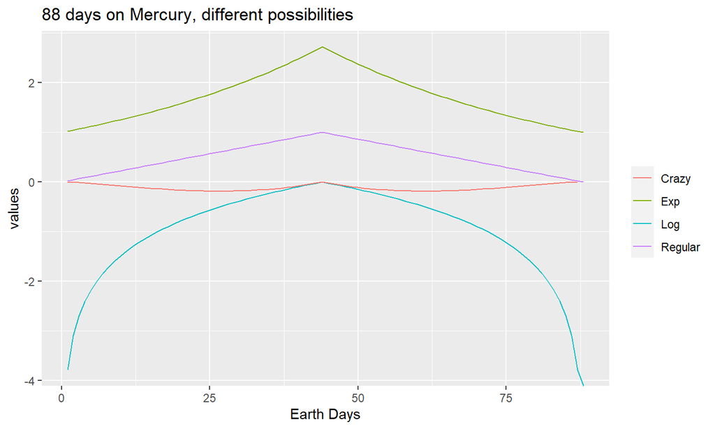